# Data Wrangling: SQL

CMSC320

2016-09-18

*This material is based on Amol Deshpande’s notes: https://github.com/umddb/datascience-fall14/blob/master/lecture-notes/relational.md*

In the previous section we looked at common operations used in data manipulation using the `dplyr` package. In this section we go over the same manipulation operations using SQL (Structured Query Language). We then conclude with other SQL constructs beyond these common manipulation operations. First, however, a quick overview of database technology and SQL.

Database Management Systems were introduced by Ted Codd in the late 60’s – early 70’s. They are centered around the relational data model (which we saw before) and seeks to achieve the following:

- Separation of logical, physical data models (data independence)
- Declarative query languages (as opposed to imperative programming)
- Formal semantics (e.g., the ER Data Model)
- Query optimization (key to commercial success)
- 1st prototypes:
  - Ingres -> CA
  - Postgres -> Illustra -> Informix -> IBM
  - System R -> Oracle, DB2

As a reminder, the key components of the Relational Data Model are: - Relations (Tables) - Rows, or Tuples, or Records, Entities - Columns, or Attributes - Schema

Remember also the distinction between a *Relation Schema* (a list of attributes and their domain) and a *Relation Instance* (a particular instantiation of a relation with actual values, which will change over time).

### Formal introduction to keys

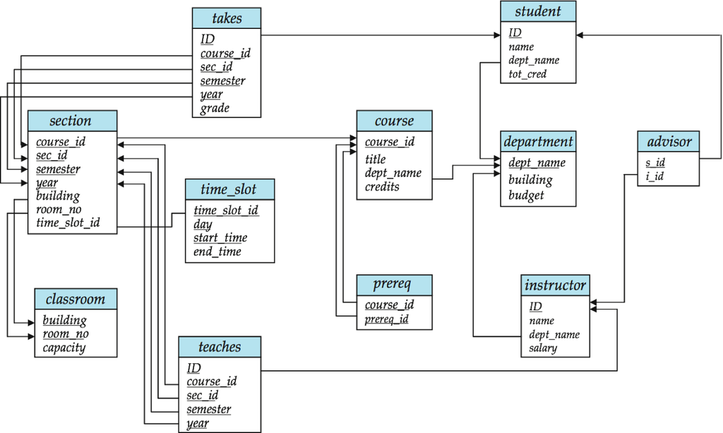

- Attribute set $K$ is a **superkey** of relation $R$ if values for $K$ are sufficient to identify a unique tuple of each possible relation $r(R)$
  - Example: `{ID}` and `{ID,name}` are both superkeys of *instructor*
- Superkey $K$ is a **candidate key** if $K$ is minimal
  - Example: `{ID}` is a candidate key for Instructor
- One of the candidate keys is selected to be the **primary key**
  - Typically one that is small and immutable (doesn’t change often)
  - Primary key typically highlighted
- **Foreign key**: Primary key of a relation that appears in another relation
  - `{ID}` from *student* appears in *takes, advisor*
  - *student* called referenced relation
  - *takes* is the referencing relation
  - Typically shown by an arrow from referencing to referenced
- **Foreign key constraint**: the tuple corresponding to that primary key must exist
  - Imagine:
    - Tuple: `('student101', 'CMSC302')`in *takes*
    - But no tuple corresponding to ‘student101’ in *student*
  - Also called referential integrity constraint

#### Keys: Examples

- Married(person1-ssn, person2-ssn, date-married, date-divorced)
- Account(cust-ssn, account-number, cust-name, balance, cust-address)
- RA(student-id, project-id, superviser-id, appt-time, appt-start-date, appt-end-date)
- Person(Name, DOB, Born, Education, Religion, …)
  - Information typically found on Wikipedia Pages
- President(name, start-date, end-date, vice-president, preceded-by, succeeded-by)
  - Info listed on Wikipedia page summary
- Rider(Name, Born, Team-name, Coach, Sponsor, Year)
  - Tour de France: Historical Rider Participation Information

### SQL Basics Overview

The Structured Query Language (SQL) is both a *Data Definition Language* and a *Data Manipulation Language*

```sql
CREATE TABLE <name> ( <field> <domain>, ... )

INSERT INTO <name> (<field names>) VALUES (<field values>)

DELETE FROM <name> WHERE <condition>

UPDATE <name> SET <field name> = <value> WHERE <condition>

SELECT <fields> FROM <name> WHERE <condition>
```

Consider the following example schema:

- Movie(title, year, length, inColor, studioName, producerC#)
- StarsIn(movieTitle, movieYear, starName)
- MovieStar(name, address, gender, birthdate)
- MovieExec(name, address, cert#, netWorth)
- Studio(name, address, presC#)

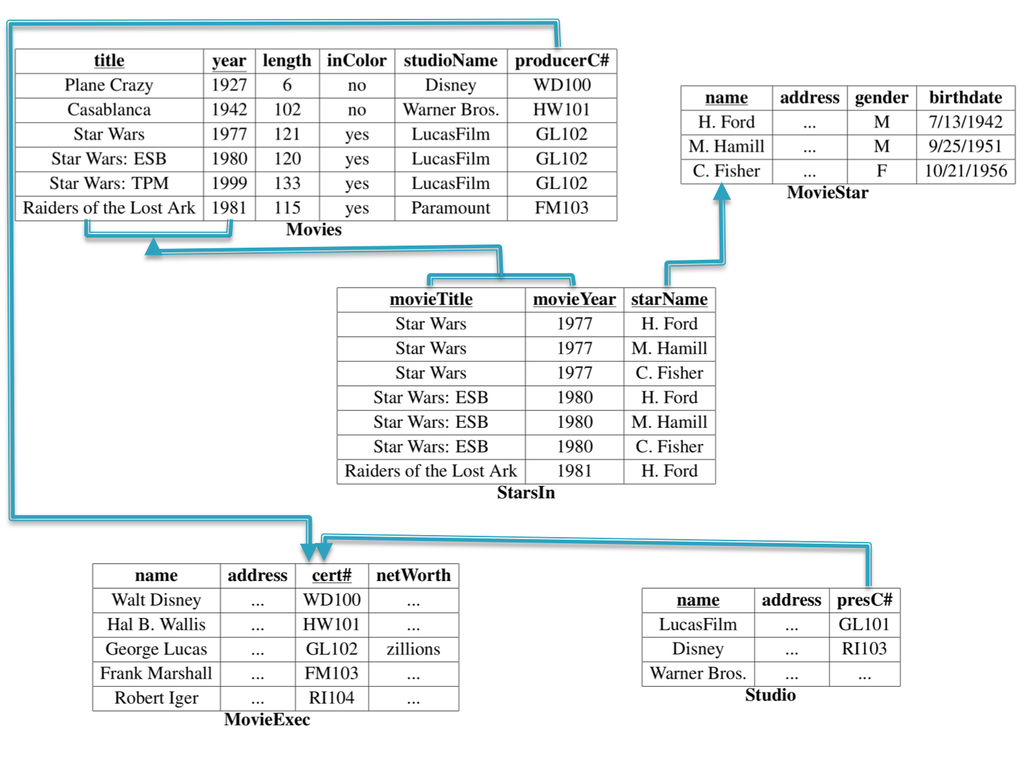

We use SQL as a *Data Definition Language* to define this schema:

```sql
create table movieExec (
  name char(30),
  address char(100),
  cert# integer primary key,
  networth integer
);

create table movie (
  title char(100),
  year integer,
  length integer,
  inColor smallint,
  studioName char(20),
  producerC# integer references
  movieExec(cert#)
);
```

- Must define movieExec before movie. Why ?
- Notice that we define *types* (we haven’t done that explicitly in R)

Statements to add or remove data from a relation:

```sql
insert into StarsIn values('King Kong', 2005, 'Naomi Watts');
insert into StarsIn(starName, movieTitle, movieYear)
  values('Naomi Watts', 'King Kong', 2005);

delete from movies where movieYear < 1980;
```

### SQL Constructs: Single Table Queries

Here we will see the same operations we saw with `dplyr`, but there is a fundamental difference. SQL is a declarative language, we don’t write how to get the answer we want, we declare the answer we want. The actual execution is determined and optimized by the database engine. However, there are clear mappings between parts of SQL queries and the operations we used in `dplyr`. The basic construct in SQL is the so-called `SFW` construct: *select-from-where* which specifies:

- *select*: which attributes you want the answer to have
- *from*: which relation (table) you want the answer to be computed from
- *where*: what conditions you want to be satisfied by the rows (tuples) of the answer

E.g.: movies produced by disney in 1990: note the *rename*

```sql
select m.title, m.year
from movie m
where m.studioname = 'disney' and m.year = 1990
```

The **select** clause can contain expressions

- `select title || ' (' || to_char(year) || ')' as titleyear`
- `select 2014 - year`

The **where** clause support a large number of different predicates and combinations thereof

- `year between 1990 and 1995`
- `title like 'star wars%'` `title like 'star wars _'`

We can include ordering, e.g., find distinct movies sorted by title

```sql
select distinct title
from movie
where studioname = 'disney' and year = 1990
order by title;
```

### Group-by and summarize

As expected, SQL has an idiom for grouping and summarizing (*conditioning* as we called it before). Remember this is a very important concept that shows up in many data processing platforms

- What it does: Partition the tuples by the group attributes (*year* in this case), and do something (*compute avg* in this case) for each group
- Number of resulting tuples == Number of groups

E.g., compute the average movie length by year

```sql
select name, avg(length)
from movie
group by year
```

### Subqueries

You can nest queries as an expression in an SFW query. We refer to these “subqueries” as “nested subquery”:

E.g., find movie with the maximum length

```sql
select title, year
from movie
where movie.length = (select max(length) from movie);
```

```sql
select *
from movies m
where 5 >= (select count(*)
            from starsIn si
            where si.title = m.title and si.year = m.year);
```

The nested subquery counts the number of actors for that movie.

E.g., rank movies by their length.

```sql
select title, year, (select count(*)
                    from movies m2
                    where m1.length <= m2.length) as rank
from movies m1;
```

Key insight: A movie is ranked 5th if there are exactly 4 movies with longer length. Most database systems support some sort of a *rank* keyword for doing this. Notice that the above query doesn’t work in presence of ties etc.

### Exercise

The `dplyr` package has a nice interface to database systems as well. As you may imagine, mapping the `dplyr` single and two-table verbs to SQL can be pretty straight forward. However, it also allows you to run SQL queries on these databases directly. See more information [in this introduction](https://cran.r-project.org/web/packages/dplyr/vignettes/databases.html).

As an exercise you should try to answer our `dplyr` exercise questions using SQL queries and compare the results. As a reminder, here are the six questions:

*Question 1*: Filter flights to include only flights with an arrival delay greater than 2 hours (delays are recorded in minutes).

*Question 2*: Select columns in the flights table that contain delay times (note that the function `matches` can be used to select columns with names that partially match a given string. See `?dplyr::select`)

*Question 3*: Find the minimum arrival delay (this can be a negative number) in the flights table. Use `summarize`.

*Question 4*: Find minimum arrival delay (again, can be a negative number) in the flights table for each *destination* airport. Use `group_by` and `summarize`.

*Question 5*: List the name of **all** airlines and the number of flights for each airline in flights table. The `airlines` table contains airline names, so you will have to perform a join operation.

*Question 6*:

1. Create a new column (use `mutate`) with total delay time for each flight.
2. Replace any missing *total delay times* with the average (`mean`) total delay.
3. Same as (b) but now replace any missing *total delay times* with the average (`mean`) total delay for the flight’s route (i.e., origin/destination combination)

### Other useful SQL constructs

- Set operations

```sql
select name
from movieExec
union/intersect/minus
select name
from movieStar
```

- Set Comparisons

```sql
select *
from movies
where year in [1990, 1995, 2000];

select *
from movies
where year not in (
  select extract(year from birthdate)
  from MovieStar
);
```

### SQL Constructs: Multi-table Queries

Key idea: - Do a join to get an appropriate table - Use the constructs for single-table queries

You will get used to doing all at once

- Examples:

```sql
select title, year, me.name as producerName
from movies m, movieexec me
where m.producerC# = me.cert#;
```

- Consider the query:

```sql
select title, year, producerC#, count(starName)
from movies, starsIn
where title = starsIn.movieTitle and year = starsIn.movieYear
group by title, year, producerC#
```

- What about movies with no stars ?
- Need to use **outer joins**

```sql
select title, year, producerC#, count(starName)
from movies left outer join starsIn
  on title = starsIn.movieTitle and year = starsIn.movieYear
group by title, year, producerC#
```

As we saw before, all tuples from ‘movies’ that have no matches in starsIn are included with NULLs (in `dplyr` this was `NA`). So, if a tuple `(m1, 1990)` has no match in `starsIn`, we get `(m1, 1990, NULL)` in the result and the `count(starName)` works correctly then. Note however that `count(*)` would not work correctly (NULLs can have unintuitive behavior)

### Other SQL Constructs

#### Views

```sql
create view DisneyMovies
select *
from movie m
where m.studioname = 'disney';
```

Can use it in any place where a tablename is used. Views are used quite extensively to: (1) simplify queries, (2) hide data (by giving users access only to specific views). Views maybe *materialized* or not.

#### NULLs

Value of any attribute can be NULL if value is unknown, or it is not applicable, or hidden, etc. It can lead to counterintuitive behavior. For example, the following query does not return movies where `length = NULL`

```sql
select * from movies where length >= 120 or length <= 120`
```

Aggregate operations can be especially tricky when NULLs are present.

### DBMS are systems

Database management systems are software applications designed for very efficient manipulation of data targeting a relatively small number of operations. Since they are also defined to operate over a fairly restrictive data model, they are extremely useful in situations where data consistency and safety are required. Here are some examples of capabilities found in DBMS that help in that regard:

- Transactions
  - A transaction is a sequence of queries and update statements executed as a single unit
  - For example, transferring money from one account to another
    - Both the *deduction* from one account and *credit* to the other account should happen, or neither should
- Triggers
  - A trigger is a statement that is executed automatically by the system as a side effect of a modification to the database
- Integrity Constraints
  - Predicates on the database that must always hold
  - Key Constraints: Specifiying something is a primary key or unique

```sql
CREATE TABLE customer (
  ssn CHAR(9) PRIMARY KEY,
  cname CHAR(15), address CHAR(30), city CHAR(10),
  UNIQUE (cname, address, city));
```

Attribute constraints: Constraints on the values of attributes

`bname char(15) not null`

`balance int not null, check (balance >= 0)`

- Referential integrity: prevent dangling tuples

```sql
CREATE TABLE  branch(bname CHAR(15) PRIMARY KEY, ...);
CREATE TABLE loan(..., FOREIGN KEY bname REFERENCES branch);
```

- Can tell the system what to do if a referenced tuple is being deleted
- Global Constraints
- Single-table

```sql
CREATE TABLE branch (...,
  bcity  CHAR(15),
  assets INT,
  CHECK (NOT(bcity = ‘Bkln’) OR assets > 5M))
```

- Multi-table

```sql
CREATE ASSERTION loan-constraint
  CHECK (NOT EXISTS (
    SELECT   *
    FROM loan AS L
    WHERE  NOT EXISTS(
      SELECT   *
      FROM borrower B, depositor D, account A
      WHERE B.cname = D.cname  AND
        D.acct_no = A.acct_no  AND
        L.lno  = B.lno)))
```